# Primer of Ecology with $\textsf{R}$: chapter 6 problems

Compiled on Thu Nov 21 09:27:00 2019 by ohara

# Chapter 6 Problems: Enemy-Victim Interactions

## 6.1. Lotka–Volterra Predator–prey Model

1. Write down the two species Lotka–Volterra predator–prey model.
2. Describe how Fig. 6.4 illustrates neutral oscillatory dynamics.
3. What are the units of the predator–prey model coefficients $b$, $a$, $e$, and $s$? How do we interpret them?

### Casey:

1. This is just copy and paste… but I’ll put it here so I can refer in part c.
   $$\frac{dH}{dt} = bH - aPH$$
   $$\frac{dP}{dt} = eaPH - sP$$
2. Fig. 6.4 shows isoclines for herbivore and predator in a Lotka-Volterra model; because the line beginning from any starting point progresses around the diagram in such a way as to meet back up with itself, we know that the populations for herbivores and predators oscillate between high and low (i.e. low predators $\rightarrow$ high prey $\rightarrow$ high predators $\rightarrow$ low prey $\rightarrow$ low predators), and then return to their original populations, only to start again.
3. The parameters: in all cases, the parameter units times the units of the variables by which they’re multiplied must result in a rate of change of prey or predators.
   - $b$ is effectively the per capita birth rate (or difference between fecundity and natural death rate) for herbivores, in units of herbivores per herbivore per unit time.
   - $a$ is the attack rate of predators on herbivores, the rate at which predators kill the herbivores. The units of this are in herbivores per predator per herbivore per unit time, or 1/(predators * time).
   - $e$ is the efficiency at which predators convert eaten prey into baby predators. $aPH$ is the number of herbivores eaten, a proportion $e$ of which are instantaneously converted into new predators. The units would have to be predators per herbivore.
   - $s$ is the constant instantaneous death rate of predators. It is unitless - just a proportion.

## 6.2. Rosenzweig-MacArthur Predator–prey Model

1. Write down the two species Rosenzweig-MacArthur predator–prey model.
2. How do we interpret $b$, $K$, $w$, $D$, $e$ and $s$? What are their units?
3. What is the value of the functional response when $H = D$? Explain how this result provides the meaning behind the name we use for $D$, the half saturation constant.
4. For each point A–D in Fig. 6.5, determine whether the growth rate for the predator and the herbivore are zero, positive, or negative.
5. In what way is the Rosenzweig-MacArthur predator isocline (Fig. 6.5) similar to the Lotka–Volterra model? It also differs from the Lotka–Volterra isocline – explain the ecological interpretation of $D$ in the type II functional response and its consequence for this isocline.
6. Explain the interpretation of real and imaginary parts of the eigenvalues for this paramterization of the Rosenzweig-MacArthur predator–prey model.
7. In what ways does Fig. 6.6a match the interpretation of the eigenanalysis of this model?
8. Examine the prey isoclines in Fig. 6.6a. How you can tell what the carrying capacities of the prey are?
9. What do the above eigenanalyses tell us about how the stability of the predator–prey interaction varies with the carrying capacity of the prey?
10. Consult Fig. 6.6a. What is the relation between the carrying capacity of the prey and the magnitude of the oscillations? What is the relation between the carrying capacity of the prey and the minimum population size? What does this interpretation imply about natural ecosystems?

### Casey:

1. again, copy and paste of Rosenzweig-MacArthur model for reference.
   $$\frac{dH}{dt}= bH(1 - \alpha H)- w \frac{H}{D + H} P$$
   $$\frac{dP}{dt}= ew\frac{H}{D + H} P - sP$$
2. As for the Lotka Volterra model, the units of each parameter must allow that the result is in terms of rate of change of prey or predators.
   - $b$ is the same as for the Lotka-Volterra model.
   - $K$ there’s no $K$ but the $\alpha$ term is $1/K$, i.e. the marginal effect of an additional herbivore on the rate of growth. Units of $\alpha$ would be 1/prey, so units of $K$ would be units of prey.
   - $w$ is the maximum capture rate, in units of prey per predator per unit time.
   - $D$ is the half-saturation value, in units of prey.
   - $e$ is the same as for the Lotka-Volterra model.
   - $s$ is the same as for the Lotka-Volterra model.
3. When $H = D$, the $\frac{H}{D + H}$ term becomes 0.5, or the capture rate $w \frac{H}{D + H}$ becomes half the maximum capture rate. Thus the term half-saturation value.
4. I don’t see points A-D in figure 6.5… roughly, for prey species below about 550, the predator population growth will be negative, and positive above that. Above the solid curve, the prey population will decrease, and below the prey population will increase.
5. The predator isocline for R-M model is similar to the L-V model, in that it is a constant value. The prey isocline is now curved downward due to the handling time implied by the $D$ term combined with the $\alpha$ term: the $D$ term on its own implies an upward slope to the isocline (predators are less effective at controlling prey since they have to spend a little time eating them, so for greater prey numbers, more predators are needed to keep the prey population at zero growth). The downward curve comes from the carrying capacity effect of the $\alpha$ term.
6. in eigenanalysis of the R-M Jacobian, the real portion of the eigenvalue is related to the instantaneous growth rate of the population (where a negative indicates a stable attractor drawing the system toward stability, and positive indicates unstable attractor pushing the system to a stable oscillation); the imaginary portion is related to oscillations around a stable point.
7. Figure 6.6a shows the interpretation of f) by showing that the system moves away from a stable equilibrium toward what may become a stable oscillation around the various quadrants of the system. As an example, I changed the setup for Fig. 6.5 to have $\alpha = 0.0005$ instead of 0.001 (doubling the carring capacity). In this case, the eigenvalues have positive real parts so the system pushes toward an oscillation regime.

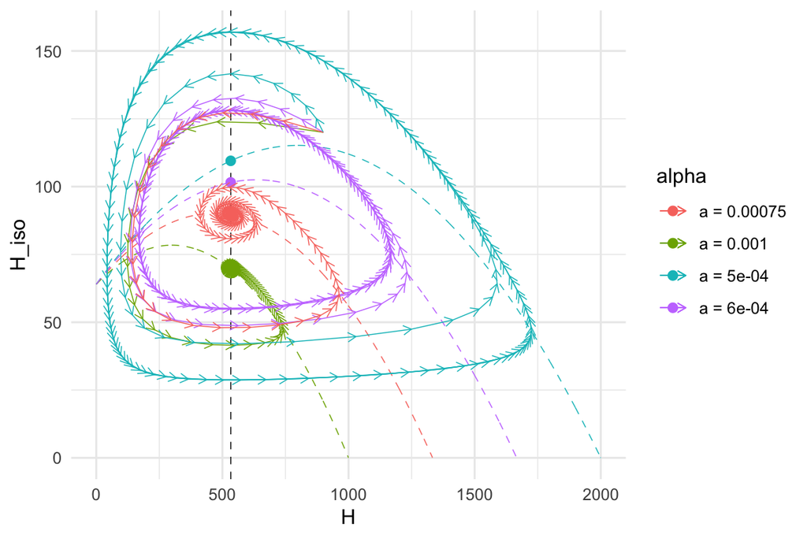

8. From Fig. 6.6a, we can tell the carrying capacity of the prey by looking at the dynamics around the solid line, particularly where predator population drops to zero and the solid line intersects the x axis - in the absence of predators, the prey population will self-stabilize. In this case, $K = 2000$.
9. The stability of the predator–prey interaction varies with the carrying capacity of the prey - as the carrying capacity increases, the “hump” of the prey isocline moves rightward, and when the peak passes the predator isocline, the system moves toward stable oscillations increasingly distant from the equilibrium point.
10. What is the relation between the carrying capacity of the prey and the magnitude of the oscillations? The higher the carrying capacity, the greater the magnitude of oscillations.
    - What is the relation between the carrying capacity of the prey and the minimum population size? The higher the carrying capacity, the closer the minimum prey population size approaches the vertical axis.
    - What does this interpretation imply about natural ecosystems? It seems as if other parameters (e.g. $D$) might compensate for a system where prey has a high carrying capacity.

## 6.3. Effects of dispersion on host–parasitoid dynamics

1. Demonstrate the effects of aggregation on host–parasitoid dynamics. Specifically, vary the magnitude of $k$ to find the effects on stability.
2. Demonstrate the effects of $a$ on stability.
3. Demonstrate the effects of $R$ on stability.

## 6.4. Effects of age at onset and disease duration on outbreak periodicity

1. Create three simulations showing how diseases of different durations influence the periodicity of the outbreaks.
2. Create three simulations showing how the age at onset for different diseases influence the periodicity of the outbreaks.
3. Consider which factor is more important in influencing outbreak interval. How do you measure the interval? What criteria would you use to determine “importance”? How do the realities of age and duration influence your selection of criteria? Write a short essay that asserts a thesis, and then provides support based on this exercise.